# RTSS Project Report

October 07, 2017

## Experimental Design

Bulk RNASeq experiment assessing the effect of different stimulation on subjects treated with the RTSS malaria vaccine or comparator. There were a total of 1895 samples.

**Subjects**: 500 subjects.

**Vaccine**: rtss and comparator

**Stimulation**: dmso, csp, hbs

**Location**: bagamoyo and manhica

**Age**: 6-12 weeks (young) and 5-17 months (old).

**Outcome**: control (no malaria) and case (malaria)

**Visit**: M0 and M3 (initial visit and 3 months later)

## Analysis

Reads were aligned using BWA Aln version 0.7.10. The transcriptome was downloaded from UCSC RefSeq (Human 19 or Mouse 10). Mitochondrial genes and ERCC reference sequences were added. Sequence alignment and quantification were run at Broad Technology Labs. The data was voom transformed and a linear model was applied for statistical testing.

There were 1380 samples and 11364 genes remaining after filtering.

## Statistical Analysis

Test disease stimulation interaction on only M0 samples. (y~disease*stimulation)

Test stimulation visit interaction on both M0 and M3 sites. RTSS samples only. Only includes samples where stimulation samples are present in both M0 and M3 (y~stimulation*visit)

Test disease effects (malaria factor) on M3 samples (rtss and comparator) for age levels together and separately. (y~disease)

## Sample Sizes: disease stimulation interaction (M0 only)

Bagamoyo

|  | no malaria | malaria | comparator | rtss |
| --- | --- | --- | --- | --- |
| dmso | 98 | 14 | 36 | 76 |
| csp | 97 | 15 | 35 | 77 |
| hbs | 89 | 12 | 32 | 69 |

Manhica

|  | no malaria | malaria | comparator | rtss |
| --- | --- | --- | --- | --- |
| dmso | 11 | 0 | 3 | 8 |
| csp | 10 | 0 | 3 | 7 |
| hbs | 9 | 0 | 3 | 6 |

## M0 malaria:stim: csp

No significant gene sets found

## M0 malaria:stim: hbs

|  | NGenes | Direction | PValue | FDR |
| --- | --- | --- | --- | --- |
| TBA (M72.0) | 21 | Down | 6.37e-05 | 0.0169 |

## GSEA summary disease:stimulation interaction

### FDR cutoff: 0.2

Number of significant BTM gene sets for dmso versus stimulants and disease interaction effects.

|  | interaction |
| --- | --- |
| csp | 0 |
| hbs | 1 |

## Sample Sizes: visit stimulation interaction (RTSS only)

Bagamoyo

|  | no malaria | malaria | M0 | M3 |
| --- | --- | --- | --- | --- |
| dmso | 132 | 18 | 75 | 75 |
| csp | 132 | 18 | 75 | 75 |
| hbs | 118 | 18 | 68 | 68 |

Manhica

|  | no malaria | malaria | M0 | M3 |
| --- | --- | --- | --- | --- |
| dmso | 12 | 0 | 6 | 6 |
| csp | 12 | 0 | 6 | 6 |
| hbs | 10 | 0 | 5 | 5 |

## M3-M0 csp-DMSO interaction

No significant gene sets found

## M3-M0 hsb-DMSO interaction

No significant gene sets found

## Sample Sizes: visit stimulation interaction (Comparator only)

Bagamoyo

|  | no malaria | malaria | M0 | M3 |
| --- | --- | --- | --- | --- |
| dmso | 58 | 10 | 34 | 34 |
| csp | 56 | 10 | 33 | 33 |
| hbs | 54 | 6 | 30 | 30 |

Manhica

|  | no malaria | malaria | M0 | M3 |
| --- | --- | --- | --- | --- |
| dmso | 6 | 0 | 3 | 3 |
| csp | 4 | 0 | 2 | 2 |
| hbs | 6 | 0 | 3 | 3 |

## M3-M0 csp-DMSO interaction

|  | NGenes | Direction | PValue | FDR |
| --- | --- | --- | --- | --- |
| Resting dendritic cell surface signature (S10) | 43 | Up | 0.000334 | 0.0884 |

## M3-M0 hsb-DMSO interaction

No significant gene sets found

## GSEA summary visit:stimulation interaction

### FDR cutoff: 0.2

|  | visit:stimulation interaction |
| --- | --- |
| csp | 1 |
| hbs | 0 |

## Sample Sizes: disease effects for DMSO (M3 only)

Bagamoyo

|  | no malaria | malaria | comparator | rtss |
| --- | --- | --- | --- | --- |
| young | 164 | 35 | 73 | 126 |
| old | 0 | 0 | 0 | 0 |

Manhica

|  | no malaria | malaria | comparator | rtss |
| --- | --- | --- | --- | --- |
| young | 20 | 1 | 8 | 13 |
| old | 105 | 24 | 50 | 79 |

## M3 malaria effects DMSO both

|  | NGenes | Direction | PValue | FDR |
| --- | --- | --- | --- | --- |
| enriched in NK cells (I) (M7.2) | 45 | Down | 8.12e-05 | 0.0215 |
| chemokine cluster (I) (M27.0) | 20 | Down | 0.000704 | 0.0933 |

## M3 malaria effects DMSO young

|  | NGenes | Direction | PValue | FDR |
| --- | --- | --- | --- | --- |
| chemokine cluster (I) (M27.0) | 20 | Down | 4.3e-05 | 0.0114 |
| heme biosynthesis (II) (M222) | 10 | Down | 0.000321 | 0.0425 |
| AP-1 transcription factor network (M20) | 13 | Down | 0.00403 | 0.157 |
| respiratory electron transport chain (mitochondrion) (M219) | 18 | Down | 0.00445 | 0.157 |
| chaperonin mediated protein folding (I) (M204.0) | 14 | Down | 0.00486 | 0.157 |
| respiratory electron transport chain (mitochondrion) (M231) | 11 | Down | 0.00526 | 0.157 |
| enriched in T cells (II) (M223) | 11 | Down | 0.0053 | 0.157 |
| enriched in NK cells (I) (M7.2) | 45 | Down | 0.00547 | 0.157 |
| proinflammatory cytokines and chemokines (M29) | 9 | Down | 0.00552 | 0.157 |
| B cell surface signature (S2) | 70 | Up | 0.00592 | 0.157 |

[output cut: 13 more lines]

## M3 malaria effects DMSO old

|  | NGenes | Direction | PValue | FDR |
| --- | --- | --- | --- | --- |
| enriched in NK cells (I) (M7.2) | 45 | Down | 3.76e-05 | 0.00996 |
| signaling in T cells (II) (M35.1) | 10 | Down | 0.000423 | 0.0561 |

## GSEA summary disease effects for DMSO stimulation

### FDR cutoff: 0.2

Number of significant BTM gene sets for malaria effects for DMSO samples.

|  | disease |
| --- | --- |
| both | 2 |
| young | 23 |
| old | 2 |

## DEG: M0 malaria1:stimulationcsp

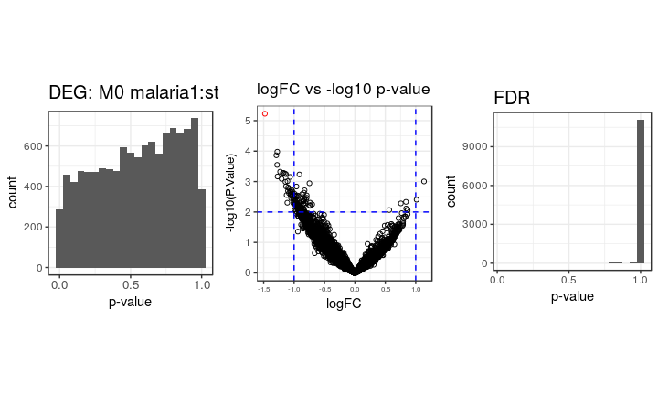

## DEG: M0 malaria1:stimulationcsp

|  | log FC | P.value | FDR |
| --- | --- | --- | --- |
| KIF18A | -1.48 | 5.92e-06 | 0.0672 |
| ATMIN | -1.28 | 0.000105 | 0.517 |
| IFT122 | -1.29 | 0.000137 | 0.517 |
| EMC8 | -1.28 | 0.000283 | 0.662 |
| SLC35B3 | -1.23 | 0.000473 | 0.662 |
| BCL3 | -1.17 | 0.000519 | 0.662 |
| ZNF275 | -1.19 | 0.000523 | 0.662 |
| STX5 | -1.15 | 0.000548 | 0.662 |
| PRR3 | -1.13 | 0.000568 | 0.662 |
| HUWE1 | -0.912 | 0.000583 | 0.662 |

[output cut: 114 more lines]

## DEG: M0 malaria1:stimulationhbs

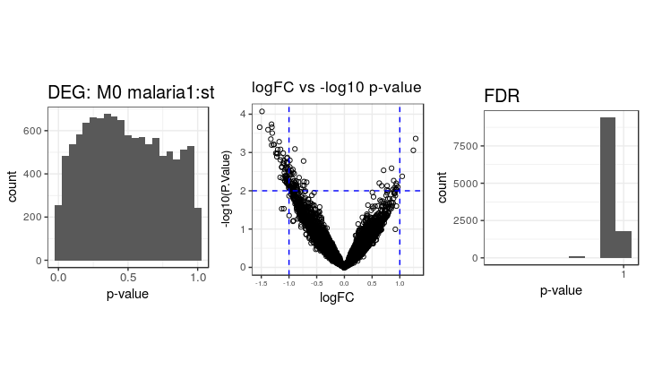

## DEG: M0 malaria1:stimulationhbs

|  | log FC | P.value | FDR |
| --- | --- | --- | --- |
| ST7L | -1.49 | 8.46e-05 | 0.576 |
| ATP5SL | -1.31 | 0.000182 | 0.576 |
| UBE2F | -1.31 | 0.000218 | 0.576 |
| CHPT1 | -1.53 | 0.000219 | 0.576 |
| NR1D2 | -1.38 | 0.000253 | 0.576 |
| YWHAH | -1.3 | 0.000311 | 0.59 |
| OCEL1 | 1.29 | 0.000431 | 0.604 |
| RDH13 | -1.33 | 0.000447 | 0.604 |
| MED27 | -1.18 | 0.000523 | 0.604 |
| SNX19 | -1.28 | 0.000618 | 0.604 |

[output cut: 121 more lines]

## DEG summary disease:stimulation interaction

### FDR cutoff: 0.2

Number of significant genes for dmso versus stimulants and disease interaction effects.

|  | interaction |
| --- | --- |
| csp | 1 |
| hbs | 0 |

## DEG: M3-M0 csp-DMSO interaction visitM3:stimulationcsp

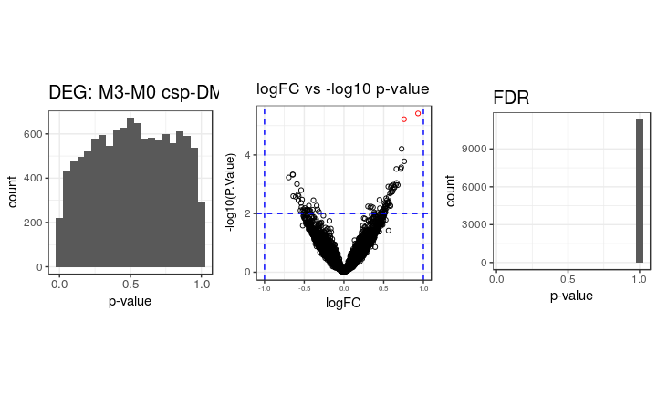

## DEG: M3-M0 csp-DMSO interaction visitM3:stimulationcsp

|  | log FC | P.value | FDR |
| --- | --- | --- | --- |
| PDK2 | 0.933 | 3.83e-06 | 0.0342 |
| IL2 | 0.757 | 6.02e-06 | 0.0342 |
| EFR3A | 0.726 | 6.21e-05 | 0.235 |
| MINOS1P1 | 0.759 | 0.000164 | 0.466 |
| RNF139 | 0.721 | 0.000263 | 0.488 |
| ACYP2 | 0.714 | 0.000299 | 0.488 |
| CCDC14 | 0.66 | 0.0003 | 0.488 |
| ADCY7 | -0.646 | 0.000463 | 0.593 |
| ZNF808 | -0.642 | 0.00047 | 0.593 |
| OGG1 | -0.695 | 0.000586 | 0.666 |

[output cut: 79 more lines]

## DEG: M3-M0 hsb-DMSO interaction visitM3:stimulationhbs

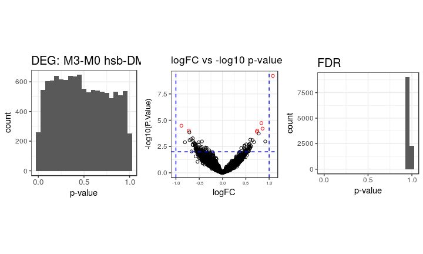

## DEG: M3-M0 hsb-DMSO interaction visitM3:stimulationhbs

|  | log FC | P.value | FDR |
| --- | --- | --- | --- |
| IL2 | 1.08 | 5.95e-10 | 6.76e-06 |
| CISH | 0.833 | 1.85e-05 | 0.105 |
| THAP3 | -0.882 | 3.3e-05 | 0.125 |
| SLC22A1 | 0.858 | 6.2e-05 | 0.176 |
| EIF4ENIF1 | -0.721 | 9.59e-05 | 0.189 |
| PTPRO | 0.745 | 9.98e-05 | 0.189 |
| LRRC1 | 0.737 | 0.000123 | 0.199 |
| PPIL1 | -0.712 | 0.000143 | 0.203 |
| PDK2 | 0.777 | 0.000185 | 0.234 |
| MORN2 | -0.639 | 0.000523 | 0.594 |

[output cut: 96 more lines]

## DEG summary visit:stimulation interaction

### FDR cutoff: 0.2

Number of significant genes for dmso versus stimulants and visit interaction effects.

|  | interaction |
| --- | --- |
| csp | 2 |
| hbs | 7 |

## DEG: M3-M0 csp-DMSO interaction visitM3:stimulationcsp

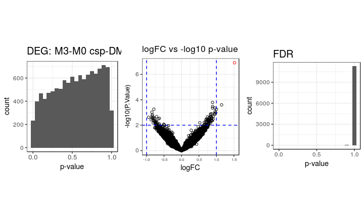

## DEG: M3-M0 csp-DMSO interaction visitM3:stimulationcsp

|  | log FC | P.value | FDR |
| --- | --- | --- | --- |
| AGPAT9 | 1.52 | 1.22e-07 | 0.00139 |
| STRN3 | 0.888 | 0.00016 | 0.784 |
| NME2 | 1.15 | 0.00025 | 0.784 |
| APOBR | 0.891 | 0.000337 | 0.784 |
| FAM159A | 0.961 | 0.000449 | 0.784 |
| BOLA1 | 0.889 | 0.00045 | 0.784 |
| S1PR4 | -0.791 | 0.000547 | 0.784 |
| LOC554206 | 1 | 0.000552 | 0.784 |
| BCL9L | 0.959 | 0.000874 | 0.903 |
| GABARAPL1 | -0.846 | 0.000942 | 0.903 |

[output cut: 88 more lines]

## DEG: M3-M0 hsb-DMSO interaction visitM3:stimulationhbs

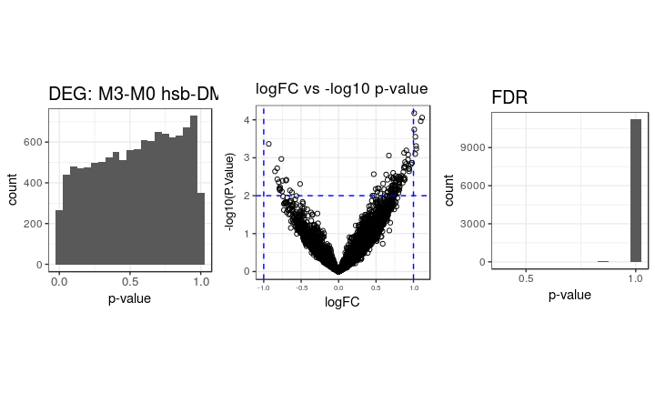

## DEG: M3-M0 hsb-DMSO interaction visitM3:stimulationhbs

|  | log FC | P.value | FDR |
| --- | --- | --- | --- |
| NAPA | 1.01 | 6.65e-05 | 0.409 |
| MAP1LC3B | 1.12 | 8.71e-05 | 0.409 |
| CFL2 | 1.1 | 0.000108 | 0.409 |
| DDX41 | 1.01 | 0.00018 | 0.512 |
| BCR | 1.03 | 0.00028 | 0.636 |
| SSBP2 | -0.932 | 0.00043 | 0.762 |
| TTC13 | 1.03 | 0.00049 | 0.762 |
| NBPF8 | 1.04 | 0.00058 | 0.762 |
| B3GNT7 | 0.904 | 0.000639 | 0.762 |
| MFSD10 | 0.875 | 0.000742 | 0.762 |

[output cut: 107 more lines]

## DEG summary visit:stimulation interaction

### FDR cutoff: 0.2

Number of significant genes for dmso versus stimulants and visit interaction effects.

|  | interaction |
| --- | --- |
| csp | 1 |
| hbs | 0 |

## DEG: both

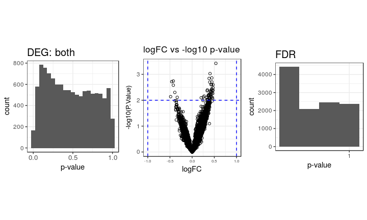

## DEG: both

|  | log FC | P.value | FDR |
| --- | --- | --- | --- |
| CCDC8 | 0.535 | 0.000376 | 0.851 |
| ABCA9 | 0.403 | 0.000935 | 0.851 |
| TTPA | 0.444 | 0.00138 | 0.851 |
| GCFC2 | 0.383 | 0.00143 | 0.851 |
| ZFP1 | -0.424 | 0.00181 | 0.851 |
| MNT | -0.46 | 0.00191 | 0.851 |
| FKTN | 0.444 | 0.00197 | 0.851 |
| CAMTA2 | 0.397 | 0.002 | 0.851 |
| LINC00263 | 0.427 | 0.00249 | 0.851 |
| SOX5 | 0.438 | 0.0025 | 0.851 |

[output cut: 40 more lines]

## DEG: young

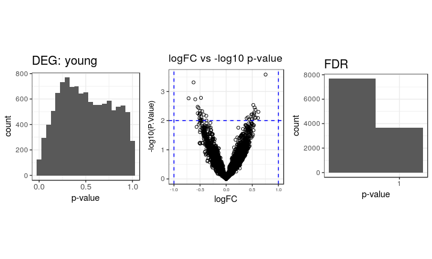

## DEG: young

|  | log FC | P.value | FDR |
| --- | --- | --- | --- |
| CCDC8 | 0.755 | 0.000263 | 0.968 |
| FAM122A | -0.624 | 0.000487 | 0.968 |
| SBDS | -0.482 | 0.00166 | 0.968 |
| CES1 | -0.719 | 0.00171 | 0.968 |
| MED12L | -0.592 | 0.00185 | 0.968 |
| CENPL | 0.52 | 0.0029 | 0.968 |
| DHCR7 | -0.546 | 0.00335 | 0.968 |
| TMEM214 | 0.546 | 0.00356 | 0.968 |
| KLF7 | -0.53 | 0.00364 | 0.968 |
| HSD3B7 | 0.56 | 0.00422 | 0.968 |

[output cut: 29 more lines]

## DEG: old

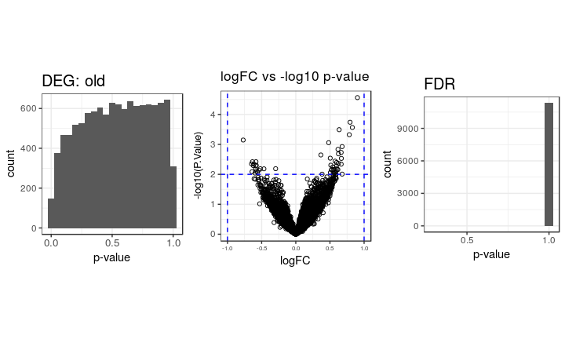

## DEG: old

|  | log FC | P.value | FDR |
| --- | --- | --- | --- |
| ARSF | 0.903 | 2.73e-05 | 0.31 |
| RFESD | 0.795 | 0.000181 | 0.915 |
| SOX5 | 0.828 | 0.000271 | 0.915 |
| GCFC2 | 0.635 | 0.000322 | 0.915 |
| TTC13 | 0.783 | 0.000473 | 1 |
| MNT | -0.77 | 0.000712 | 1 |
| CD101 | 0.481 | 0.000874 | 1 |
| KIF22 | 0.678 | 0.00118 | 1 |
| CCSER1 | 0.618 | 0.00146 | 1 |
| PATZ1 | 0.664 | 0.00185 | 1 |

[output cut: 41 more lines]

## DEG summary disease effects for DMSO stimulation

### FDR cutoff: 0.2

|  | interaction |
| --- | --- |
| both | 0 |
| young | 0 |
| old | 0 |

## Session info

R Under development (unstable) (2017-01-15 r71979) Platform: x86_64-pc-linux-gnu (64-bit) Running under: Ubuntu 14.04.2 LTS

locale: [1] LC_CTYPE=en_US.UTF-8 LC_NUMERIC=C  
[3] LC_TIME=en_US.UTF-8 LC_COLLATE=en_US.UTF-8  
[5] LC_MONETARY=en_US.UTF-8 LC_MESSAGES=en_US.UTF-8  
[7] LC_PAPER=en_US.UTF-8 LC_NAME=C  
[9] LC_ADDRESS=C LC_TELEPHONE=C  
[11] LC_MEASUREMENT=en_US.UTF-8 LC_IDENTIFICATION=C

attached base packages: [1] stats4 parallel stats graphics grDevices utils datasets [8] methods base

other attached packages: [1] stringr_1.2.0 plyr_1.8.4 DT_0.2  
[4] GSEABase_1.38.2 graph_1.54.0 annotate_1.54.0  
[7] XML_3.98-1.9 AnnotationDbi_1.38.2 IRanges_2.10.3  
[10] S4Vectors_0.14.5 xtable_1.8-2 edgeR_3.18.1  
[13] limma_3.32.7 gridExtra_2.3 ggplot2_2.2.1  
[16] data.table_1.10.4 Biobase_2.36.2 BiocGenerics_0.22.0 [19] knitr_1.17 BiocInstaller_1.26.1

loaded via a namespace (and not attached): [1] Rcpp_0.12.13 compiler_3.4.0 bitops_1.0-6 tools_3.4.0  
[5] digest_0.6.12 bit_1.1-12 jsonlite_1.5 memoise_1.1.0  
[9] evaluate_0.10.1 RSQLite_2.0 tibble_1.3.4 gtable_0.2.0  
[13] lattice_0.20-34 rlang_0.1.2 DBI_0.7 yaml_2.1.14  
[17] htmlwidgets_0.9 locfit_1.5-9.1 rprojroot_1.2 bit64_0.9-7  
[21] grid_3.4.0 rmarkdown_1.6 blob_1.1.0 magrittr_1.5  
[25] backports_1.1.1 scales_0.5.0 htmltools_0.3.6 colorspace_1.3-2 [29] labeling_0.3 stringi_1.1.5 RCurl_1.95-4.8 lazyeval_0.2.0  
[33] munsell_0.4.3